# Epidemiologische Modellierung als Reaktionsdiffusionsprozess mit FDM

# Tutoriumsaufgabe 5a

## Aufgabe:

Implemenieren Sie das FDM-Verfahren zur Lösung der Reaktionsdiffusionsgleichung für die zeitlich-räumliche Modellierung einer Epidemie auf einem Rechteckgebiet $D$. Verweden Sie homogene Neumann-Randbedingungen $\frac {\partial u}{\partial \vec {n}}|_{\partial D}=0$.

Gehen Sie wie folg vor:

- betrachten Sie einen konstanten Diffusionskoffizient $c ( x ) = c$,
- verwenden Sie konstante aber realistische Bevölkerungsdichtefunktion $B ( x ) ≡ B$, siehe Bevölkerunsgdichte Deutschland
- verwenden Sie in Tutoriumaufgabe 3 anhand der RKI Daten festgestelte Infektionsraten (konstant und zeitabhängig-'slowdown').

Definieren Sie eine Anfangslösung, die Sie als Startvektor verwenden und berechnen Sie die weitere Zeitschritte mit (beispielsweise) 'for' Schleife

## Idee

Hier wird als Gebiet D die Stadtfläche von Landau genutzt.

[figure not shown]

[Link zu den Daten](https://ec.europa.eu/eurostat/de/web/gisco/geodata/reference-data/population-distribution-demography/geostat)  
Die Annäherung der Stadtfläche erfolgt durch ein $3km \times 5km$ großes Rechteck.  
Der Diffusionskoeffizient ist als Konstante mit $c=0,00625$ festgelegt.  
Die Bevölkerungsdichte wird als Mittelwert der in den Quadranten dargestellten Einwohnerzahlen bestimmt.

```matlab
D = [2084, 2746, 6583, 2137, 1518;
      561,  644, 4195, 3867, 2385;
     1197, 1001, 1543,  636, 2203;];
c = 0.00625; %Mittelwert der Aufgabe 5c
B = mean(D(:));
```

$B= 2220 \frac{Personen}{km^2}$

## Implementation Grundlegender Parameter

```matlab
%Raumvariablen
Rasterlaenge = 50; % Die interpolierte Matrix soll eine Rasterlaenge von "Rasterlaenge" in Metern haben. Entspricht h * 1000 Metern (h ist in km also 0,05 km)

% Zeitvariablen
Tage = 50;
delta_t = 0.05; %20 Zeiteinheiten entsprechen einem Tag
Zeitschritte = floor(Tage/delta_t); %Zeitschritte für alle Tage

%Plotten ja oder nein?
global plotten=true;
global speichern=false;

% Infektionsvariablen
BasisErkrankungsrate = 0.33; %"Rate der Infektionsverbreitung" bei einer Kontaktrate: Wahrscheinlichkeit des Kontakts eines Infizierten mit einem Anfaelligen.
Wechselrate = (1/14); % von Infizierten zu Genesenen
```

## Ausweitung des Stadtgebietes auf $m/h$ und $n/h$ Punkte

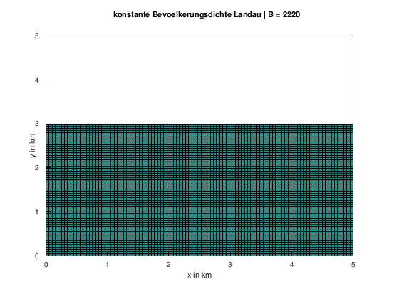

```matlab
m = rows(D);
n = columns(D);

h = Rasterlaenge / 1000; %Schrittweite in km
AnzahlPunkteProKilometer = floor(1/h); %Abrunden für ganzzahlige Anzahl Punkte innerhalb des Gebietes

M = m * AnzahlPunkteProKilometer;
N = n * AnzahlPunkteProKilometer;

global x = linspace(0, n, N);
global y = linspace(0, m, M);

clear m; %wird nicht mehr benötigt
clear n;
clear AnzahlPunkteProKilometer;

B_Interpoliert = B.*ones(M,N);


if(plotten)
  figure(9990)
  surface(x,y,B_Interpoliert)
  axis([min(min(x(:)),min(y(:))) max(max(x(:)),max(y(:))) min(min(x(:)),min(y(:))) max(max(x(:)),max(y(:)))])
   title (["konstante Bevoelkerungsdichte Landau | B = " num2str(B)]);
   ylabel("y in km")
   xlabel("x in km")

   if(speichern)
      filename=["Images/5a/Bevoelkerungsdichte.jpg"];
      saveas(9990, filename)
      %close (9990)
    endif
endif
```

## Systemmatrix für konstanten Diffusionskoeffizienten

```matlab
function A_h = KonstanteSystemmatrix (N,M,c,h) % Neumann RB
  %N: Anzahl der Gitterpunkte in x-Richtung
  %M: Anzahl der Gitterpunkte in y-Richtung
  %c: Diffusionskoeffizient konstant
  %h: Abstand der Gitterpunkte

  %-----------------------------------------------------------------------------
  % Blockmatrix B erstellen.
  % dim(B) = NxN
  B = diag(-4*ones(N,1)); %Die Matrix des Aproximationsschema fï¿½r Neumann Randbedingungen hat die Form
  tmp = diag(ones(N-1,1),1);
  B = B + tmp;
  tmp = diag(ones(N-1,1),-1);
  B = B + tmp;
  B(1,1) = -h;
  B(1,2) = h;
  B(N,N) = -h;
  B(N,N-1) = h;
  %-----------------------------------------------------------------------------
  % Blockmatrix I(Schlange) erstellen.
  % dim(I) = NxN
  I = diag(ones(N,1));
  I(1,1) = 0;
  I(N,N) = 0;
  %-----------------------------------------------------------------------------
  % Blockmatrix hI erstellen.
  % dim(hI) = NxN
  hI = h*diag(ones(N,1));
  %-----------------------------------------------------------------------------
  A_h = zeros(N*M,N*M);
  %Erste BlockZeile von A_h anpassen mit -hI und hI
  A_h(1:N,1:N) = -1*hI;
  A_h(1:N,N+1:2*N) = hI;
  %Letzte BlockZeile von A_h anpassen mit -hI und hI
  A_h(((M-1)*N)+1:M*N,((M-1)*N)+1:M*N) = -1*hI;
  A_h(((M-1)*N)+1:M*N,((M-2)*N)+1:(M-1)*N) = hI;
  %Alle Blockzeilen dazwischen anpassen mit B und I
  for i=2:M-1
    A_h((i-1)*N+1:i*N,(i-2)*N+1:(i-1)*N) = I;
    A_h((i-1)*N+1:i*N,(i-1)*N+1:(i-0)*N) = B;
    A_h((i-1)*N+1:i*N,(i-0)*N+1:(i+1)*N) = I;
  endfor
  A_h = (-1*c/(h^2))*A_h;

global plotten;
global speichern;

if(plotten)
  figure(9994)
  spy(A_h)
  if(speichern)
      filename=["Images/5a/Systemmatrix_Ah.jpg"];
      saveas(9994, filename)
      %close (9994)
    endif
endif

endfunction
```

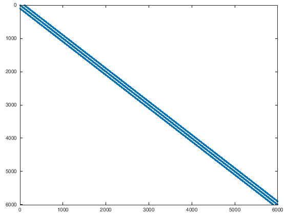

```matlab
A_h = KonstanteSystemmatrix(N,M,c,h);
```

## Startbedingungen

Position des Vinzentius-Krankenhaus wird festgelegt. Startpunkt für "patient zero".

```matlab
function [x, y, radius] = PositionVizentiusKrankenhausLandau (B, h)
 M = rows(B);
 N = columns(B);
 x = floor(N/2); %x-Koordinate des Krankenhaus
 y = floor(7*M/32);%y-Koordinate des Krankenhaus
 flaecheKrankenhaus = 0.02; % km^2 = 20.000 m^2 Umrechnung 10^6
 radiusKrankenhaus = sqrt(flaecheKrankenhaus/pi);
 %radius = 0.3/h; %radius von 300 Metern
 radius=radiusKrankenhaus/h; %
endfunction
```

```matlab
[x_KH,y_KH,r_KH] = PositionVizentiusKrankenhausLandau(B_Interpoliert, h);
InfizierteStartAnzahl = 1.5;
InitialWerte = [x_KH,y_KH,r_KH,InfizierteStartAnzahl];
clear *_KH; %Alle Variablen die mit _KH enden werden geloescht, da nicht mehr benoetigt.
```

### Infizierte in einem oder mehreren Kreisen eintragen

Diese Funktion erzeugt eine Gebiets-Matrix mit den Initialwerten der Corona-Pandemie

```matlab
function I = InfizierteStartbedingungMatrix (B,h, StartWerte)

  M = rows(B);
  N = columns(B);
  I = zeros(M,N);
  TMP = zeros(M,N);
  %Startpositionen soll eine Matrix sein mit den Eintraegen
  %[x_1-Koordinate, y_1-Koordinate, radius_1, AnzahlInfizierte_1;
  % x_2-Koordinate, y_2-Koordinate, radius_2, AnzahlInfizierte_2;
  %      ...               ...         ...
  % x_n-Koordinate, y_n-Koordinate, radius_n, AnzahlInfizierte_n;]

  AnzahlStartPositionen = rows(StartWerte); %wie viele Startpositionen gibt es? -> hier eine

  for k=1:AnzahlStartPositionen

    x_Koordinate = StartWerte(k,1);
    y_Koordinate = StartWerte(k,2);
    radius = StartWerte(k,3);
    AnzahlInfizierte = StartWerte(k,4);

    for i=1:N
      for j=1:M
        if(sqrt((i.-x_Koordinate)^2+(j.-y_Koordinate)^2) <= radius)
          I(j,i) = I(j,i) + AnzahlInfizierte/(pi*radius^2); %verteilt die absolute Infiziertenanzahl auf die vorgegebene Fläche -> jetzt erhält Infiziertendichte; I(j,i) braucht,wenn mehrere Anfangskreise gibt und die sich überschneiden, dass beide Zahlen der Kreise erhalten bleiben
        endif
      endfor
    endfor
  endfor
 % Normierung der Matrix, da fuer kleine Radien die Flaeche nicht kreisfoermig ist (daher Fehler bei Flaechenberechnung)
 sollInfizierte = round(sum(I(:)));  % Da es keine nicht natuerliche Anzahl an Personen geben kann, round rundet zur nächsten ganzen Zahl
 istInfizierte = sum(I(:)); %nicht gerundete Zahl der Infizierten
 quotient= sollInfizierte/istInfizierte;
 I = quotient*I/h^2;

%Plotten der Funktion
global plotten;
global speichern;

  if plotten
   figure(9995)
   global x; %Variable muss nicht an Funktion übergeben werden, aber Programm weiß trotzdem was in Variable steht
   global y;
   surface (x,y,I*h^2,"EdgeColor", "none"); %stellt die absolute Anzahl der Infizierten dar durch I*h^2
   title (["Startbedingungen an Tag 0: Anzahl Infizierte: " num2str(sollInfizierte)]);
   axis([min(min(x),min(y)) max(max(x),max(y)) min(min(x),min(y)) max(max(x),max(y))])
   ylabel("y")
   xlabel("x")
   colorbar
     if speichern
      filename=["Images/5a/Startbedingung_an_Tag_ 0_Anzahl_Infizierte" num2str(sollInfizierte) ".jpg"];
      saveas(9995, filename)
      %close (9995)
    endif
  endif

endfunction
```

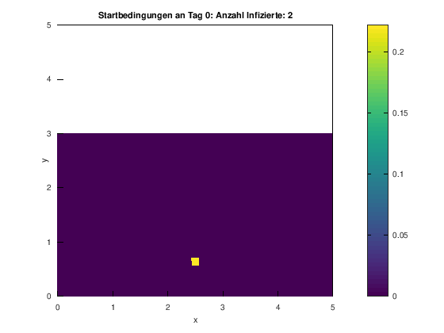

```matlab
InfizierteStartMatrix = InfizierteStartbedingungMatrix(B_Interpoliert, h, InitialWerte);
```

## Berechnung der einzelnen Tage

Beginnend mit den Anfangsbedingungen

```matlab
% *** Tag 0 ***
B = reshape(B_Interpoliert',N*M,1); %B ueberschreiben mit Vektor der interpolierten Werte; %reshape, dass Vektoren B und u_i_alt subtrahieren kann
u_i_alt = 1*reshape(InfizierteStartMatrix',N*M,1);
u_s_alt = B.-u_i_alt;
```

### Implementation des Reaktionsterms (rechte Seite)

- ist abhängig vom aktuellen Zustand der Masse im System
- stellt den Zusammenhang der räumlichen Infektionsverbreitung als Diffusionsprozess und der Kompartimentmodelle dar

#### unbeschränktes/ logistisches Wachstum - **aktuell Infizierten** (SIR)

$f_I(\vec{u}(t)) \approx F_I(\vec{u}_h(t)):= \frac{c}{B} * \vec{u_I}_h(t) * \vec{u_S}_h(t)-w\vec{u_I}_h(t)$  
wobei $\frac{c}{B}$ der logistischen Infektionsrate -> Rate der Infektionsverbreitung bei einer Kontaktrate (Wahrscheinlichkeit eines Kontaktes eines Infizierten mit einem Gefährdeten) entspricht  
$w$ ist die Wechselrate von Infizierten zu den Genesenen

```matlab
function F = F_I (Erkrankungsrate, B, Wechselrate, ui, us) %hierbei ist Erkrankungsrate=slowdown(t*delta_t) * BasisErkrankungsrate
  F = (Erkrankungsrate./B);
  F(F==Inf) = 0; %Falls B an Punkten 0 ist, dann setze hier F auf 0
  F = F.*ui.*us-Wechselrate*ui;
endfunction
```

#### unbeschränktes/ logistisches Wachstum - **Gefährdeten-Susceptibles** (SIR)

$f_S(\vec{u}(t)) \approx F_S(\vec{u}_h(t)):= -\frac{c}{B} * \vec{u_I}_h(t) * \vec{u_S}_h(t)$

```matlab
function F = F_S (Erkrankungsrate, B, ~, ui, us)
 F = -1*(Erkrankungsrate./B);
 F(F==Inf)=0; %Falls B an Punkten 0 ist, dann setze hier F auf 0
 F = F.*ui.*us;
endfunction
```

### Implementation der slowdown-Funktion

```matlab
function val=slowdown(x)
%Nach den Angegebenen Tagen wird der angegebene Prozentsatz der urspruenglichen Rate genommen
%Prozentsatz wird durch den Faktor "val" definiert

if x<14 val=1;%ursprüungliche Rate wird angenommen
%Zwischen Tag 25 (Tag der Kontaktverbote) und Tag 33 besteht Uebergangszeit
%d.h. Menschen, die sich vor den Kontaktverboten infiziert haben, werden dann erst erfasst
  elseif x<28
  val=0.4;

 elseif x<33
  val=0.3;

%Ersten 10 Tage der Kontaktverbote mit zunaechst weniger einschneidenen Maßnahmen, darueber hinaus
%haben sich nicht alle Menschen daran gehalten
  elseif x<42
  val=0.4;

%Striktere Maßnahmen zur Eindaemmung und Umdenken bei der Bevoelkerung  durch Pressemitteilungen aus Italien

  elseif x<69
  val=0.165;

%Weniger aktive Faelle und Weiterfuerhung der Beschraenkungen

elseif x<80
  val=0.09;


endif
%Beispielhafte Lockerung der Maßnahmen ab Tag 80, die die Infektionsrate wieder
%auf 50 % der Basisinfektionsrate erhoeht
%(um den Effekt der Lockerung zu beobachten)
if x>=80 val=0.5; endif
endfunction
```

### Berechnung aller Tage mithilfe des expliziten Euler-Verfahrens und des Reaktiondiffusions-Prozesses

```matlab
for t=1:Zeitschritte
  Erkrankungsrate = slowdown(t*delta_t) * BasisErkrankungsrate; %Änderung der BasisErkrankungsrate aufgrund der slowdown-Funktion

  u_i = u_i_alt + delta_t * (-A_h * u_i_alt + F_I(Erkrankungsrate, B, Wechselrate, u_i_alt, u_s_alt));
  u_s = u_s_alt + delta_t * (-A_h * u_s_alt + F_S(Erkrankungsrate, B, Wechselrate, u_i_alt, u_s_alt));

  u_i_alt = u_i;
  u_s_alt = u_s;

  Erkrankungsrate_Speicher(1,t)=Erkrankungsrate; %speichert aktuelle Erkrankungsrate für jeden Tag (da aufgrund von slowdwon variable)
  u_i_Speicher(:,t)=u_i;% die Lösungen der aktuell Infizierten werden zu jedem Zeitpunkt t gespeichert, sodass anschließend plottbar - da Lösung Vektoren sind hängt man Lösungsvektoren aneinander
  u_s_Speicher(:,t)=u_s;%  die Lösungen der susceptibles werden zu jedem Zeitpunkt t gespeichert, sodass anschließend plottbar
endfor
```

## Plotten des berechneten Reaktions-Diffuisons-prozesses

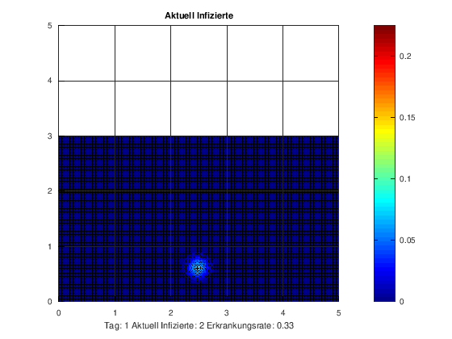

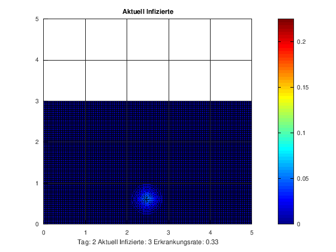

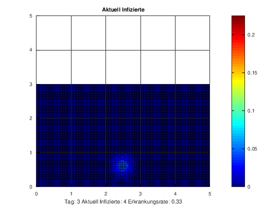

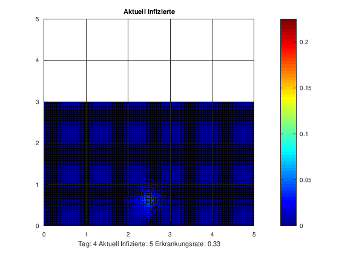

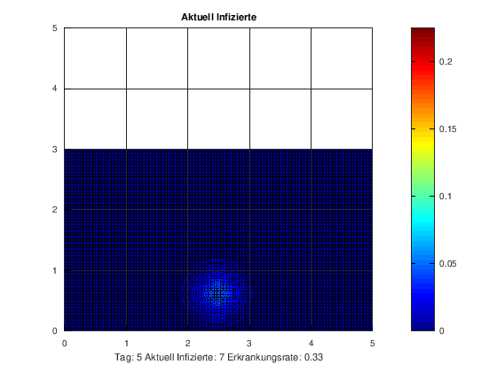

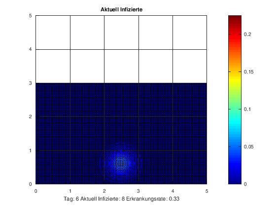

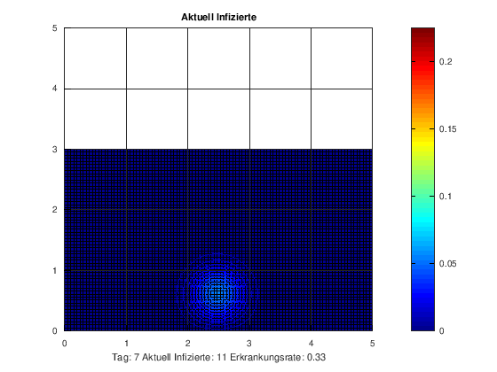

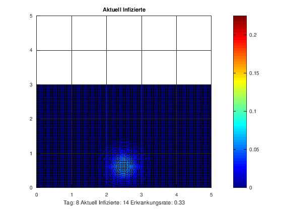

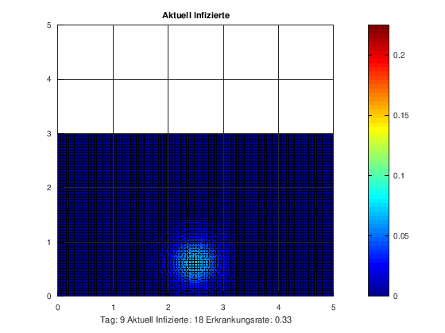

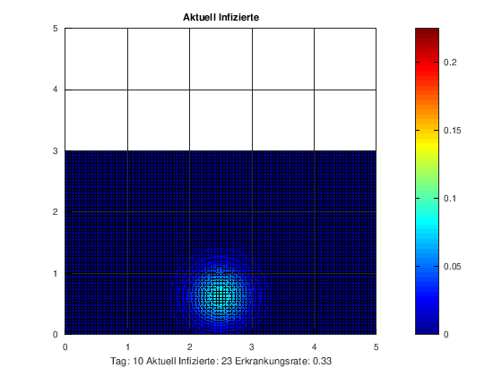

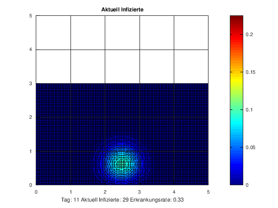

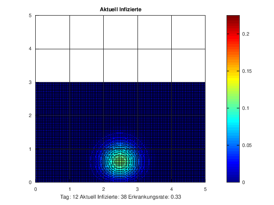

[38 more figures not shown]

```matlab
% *** Plotten der Loesungen ***

if(plotten)
fig_index=floor([1:Tage]./delta_t); %Bilder bekommen Nummern anhand von Anzahl der Tage;
                                    %gibt jeweils ein Bild für einen Tag raus -> teilt durch delta_t, da pro Tag z.B. 100 Bilder bekommt (wenn                                              delta_t=0.1) -> möchte aber nur ein Tag pro Bild und nicht 100

j=0;
 for i=fig_index
  Loesung=reshape(u_i_Speicher(:,i),N,M)'; % macht aus Lösungsvektoren eine Matrix mit N(Zeilen)x M(Spalten); transponiert noch, da reshape spaltenweise funktioniert und wir zeilenweise haben wollen
  aktuell_Infizierte=sum(Loesung(:))*h^2; % summiert alle Einträge der Matrix auf; *h^2 um absolute Anzahl der Infizierten zu erhalten
  aktuell_Infizierte_Speicher(:,i*delta_t)=aktuell_Infizierte; %speichert Gesamtinfizierten der einzelnen Tage in einer Matrix
  %disp(['Figure ',num2str(i/fig_index(1))]);
  j=j+1;
  figure(j);
  %surface(Loesung*h^2, "EdgeColor", "none")
  %colormap: autumn,  hsv jet ocean
  surfc(x,y,Loesung*h^2)% *h^2 um absolute Anzahl der Infizierten zu erhalten
  view(0,90)
  colormap ("jet")
  caxis([0,max(u_i_Speicher(:))*h^2])
  axis([min(min(x),min(y)) max(max(x),max(y)) min(min(x),min(y)) max(max(x),max(y))])
  colorbar

  title (["Aktuell Infizierte"]);
  %ylabel("y")
  xlabel(["Tag: ", num2str(delta_t*i) "\tAktuell Infizierte: " num2str(floor(aktuell_Infizierte)) "\tErkrankungsrate: " num2str(Erkrankungsrate_Speicher(1,i))])
  %Optional: Speicherung der Bilder
  %hold on;
  if (speichern)
    filename=["Images/5a/Aktuell_Infizierte_Tag_" num2str(j) "_von_" num2str(Tage) "_Raster_" num2str(M) "x" num2str(N) "_" num2str(Rasterlaenge) "m" ".jpg"];
    saveas(j, filename)
  endif
endfor
endif
```

## Animation der Lösung

Tag 1 bis 50

[figure not shown]